# EDA

Alex Furuya

5/2/2018

### Initial Steps

**Load in library.**

```r
# Loading packages
library(tidyverse)
library(ggpubr)
```

**Load in data.**

```r
# Loading data
hospice <- read_tsv("data/unprocessed/28961-0002-Data.tsv")
```

### NA Values

**Let’s see how many missing values we have.**

```r
# Looking at number of missing values
count_na <- hospice %>%
  summarise_all(funs(sum(is.na(.)))) %>%
  gather(count_na) %>%
  arrange(desc(value)) %>%
  filter(value > 0)
count_na
```

```
## # A tibble: 52 x 2
##    count_na  value
##    <chr>     <int>
##  1 PAINSTOS   9405
##  2 WHRDSCHOS  9404
##  3 PROCDX5    9404
##  4 OTHSR2OS   9404
##  5 CDDX16     9402
##  6 OTHPMTOS   9400
##  7 MCFEE2OS   9399
##  8 PSTHMEOS   9397
##  9 OTHSVCOS   9396
## 10 PROCDX4    9395
## # ... with 42 more rows
```

**The large number of NAs correspond to the variables with OS on the end, which indicate that they are “other” variables, and are there if there needs to be comments. The other variables are often “secondary” variables, which are there if the physician needs to add more than one value. Notable variables that have a large number of empty values (n = 4733 and n = 4683, correspondingly) is age of home health patients at arrival and discharge. There are few (n = 32) unavailable data for primary diagnosis, and a few (n = 22) unavailable data for whether or not the patient stayed at the same place from beginning to end of hospice care. We will omit these variables during data cleanup. Otherwise, most of the data is available.**

### Types of Variable

**Let’s look at the types of variables we have.**

```r
# Finding types of variables
table(sapply(hospice, typeof))
```

```
##
## character    double   integer
##        41         4       300
```

### Data Clean Up

**We will now begin omitting variables with many NAs, as well as index variables such as patient IDs.**

```r
# Removing ID variables
hospice_final <- hospice

hospice_final <- hospice_final %>%
  select(-PATNUM,
         -PTAGYNUM,
         -SURYEAR)

# Removing "other" variables with
hospice_final <- hospice_final %>%
  select(-DISCHRGOS,
         -WHRDSCHOS,
         -OTHEROS,
         -PREHMEOS,
         -PSTHMEOS,
         -PREHOSOS,
         -PSTHOSOS,
         -ULCRSTOS,
         -PAINTL1OS,
         -PAINFNL1,
         -PAINTL2OS,
         -PAINFNL2,
         -PAINSTOS,
         -OTHSVCOS,
         -OTHRSNOS,
         -MCFEEOS,
         -MDFEEOS,
         -GOVSRCOS,
         -PRVINSOS,
         -SOPOS,
         -OTHPMTOS,
         -MCFEE2OS,
         -MDFEE2OS,
         -OGVT2OS,
         -PVTINS2OS,
         -OTHSR2OS)
```

### Quantitative Variable Analysis

**Let’s take a look at the quantitative variables, specifically the age, pain levels and economic information.**

```r
# Looking at age
summary(hospice_final$AGEATINT)
```

```
##    Min. 1st Qu.  Median    Mean 3rd Qu.    Max.    NA's
##    0.00   59.00   75.00   68.44   84.00  100.00    4733
```

```r
summary(hospice_final$AGEATDIS)
```

```
##    Min. 1st Qu.  Median    Mean 3rd Qu.    Max.    NA's
##    0.00   70.00   80.00   77.36   87.00  100.00    4683
```

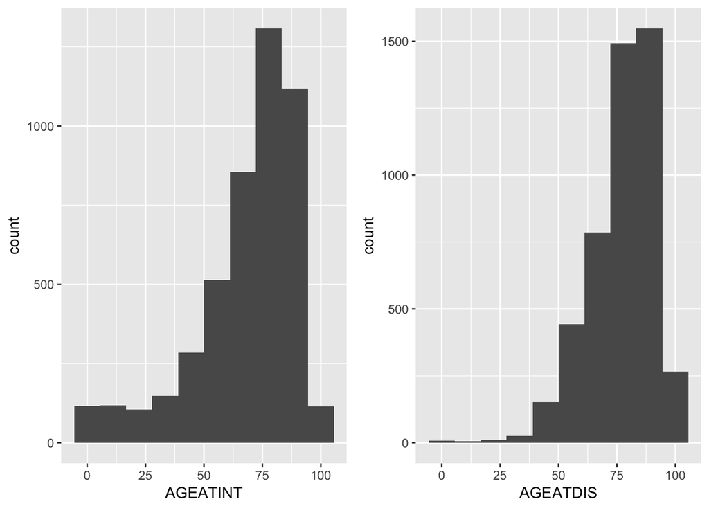

```r
# Visualizing the age information
ggarrange(
ggplot(hospice_final) + geom_histogram(mapping = aes(x = AGEATINT), bins = 10),
ggplot(hospice_final) + geom_histogram(mapping = aes(x = AGEATDIS), bins = 10),
ncol = 2,
nrow = 1)
```

```r
# Looking at pain levels
summary(filter(hospice_final, PAINLVL1 >= 0)$PAINLVL1)
```

```
##    Min. 1st Qu.  Median    Mean 3rd Qu.    Max.
##   0.000   0.000   0.000   2.189   4.000  10.000
```

```r
summary(filter(hospice_final, PAINLVL2 >= 0)$PAINLVL2)
```

```
##    Min. 1st Qu.  Median    Mean 3rd Qu.    Max.
##   0.000   0.000   1.000   1.524   3.000   5.000
```

```r
summary(filter(hospice_final, PAINREC3 >= 0)$PAINREC3)
```

```
##    Min. 1st Qu.  Median    Mean 3rd Qu.    Max.
##   0.000   0.000   0.000   1.758   3.000  10.000
```

```r
summary(filter(hospice_final, PAINREC4 >= 0)$PAINREC4)
```

```
##    Min. 1st Qu.  Median    Mean 3rd Qu.    Max.
##   0.000   0.000   0.000   1.089   2.000   5.000
```

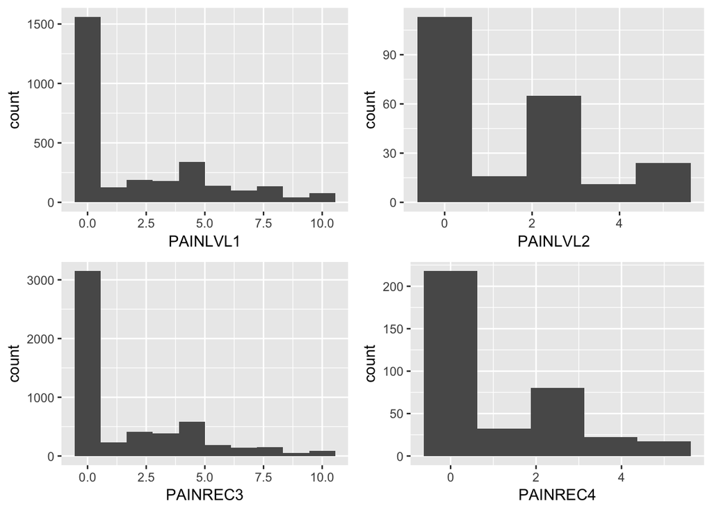

```r
# Visualizing the pain level information
ggarrange(
ggplot(filter(hospice_final,PAINLVL1 >= 0)) + geom_histogram(mapping = aes(x = PAINLVL1), bins = 10),
ggplot(filter(hospice_final, PAINLVL2 >= 0)) + geom_histogram(mapping = aes(x = PAINLVL2), bins = 5),
ggplot(filter(hospice_final, PAINREC3 >= 0)) + geom_histogram(mapping = aes(x = PAINREC3), bins = 10),
ggplot(filter(hospice_final, PAINREC4 >= 0)) + geom_histogram(mapping = aes(x = PAINREC4), bins = 5),
ncol = 2,
nrow = 2)
```

```r
# Looking at economic information
summary(filter(hospice_final, CHARGES1 >= 0)$CHARGES1)
```

```
##    Min. 1st Qu.  Median    Mean 3rd Qu.    Max.
##     0.0   421.2  1571.0  4130.1  3855.8 80000.0
```

```r
summary(filter(hospice_final, TOTBLPRD >= 0)$TOTBLPRD)
```

```
##    Min. 1st Qu.  Median    Mean 3rd Qu.    Max.
##    1.00    8.00   30.00   46.27   60.00 1000.00
```

```r
summary(filter(hospice_final, AVEDLYCH >= 0)$AVEDLYCH)
```

```
##    Min. 1st Qu.  Median    Mean 3rd Qu.    Max.
##     1.0    38.0   118.0   148.8   150.0  2000.0
```

```r
summary(filter(hospice_final, TOTCHYR >= 0)$TOTCHYR)
```

```
##    Min. 1st Qu.  Median    Mean 3rd Qu.    Max.
##    1000   41860   49146   51528   62175  120000
```

```r
summary(filter(hospice_final, TOTPAID >= 0)$TOTPAID)
```

```
##     Min.  1st Qu.   Median     Mean  3rd Qu.     Max.
##      0.0    502.8   1619.0   5111.9   4109.0 100000.0
```

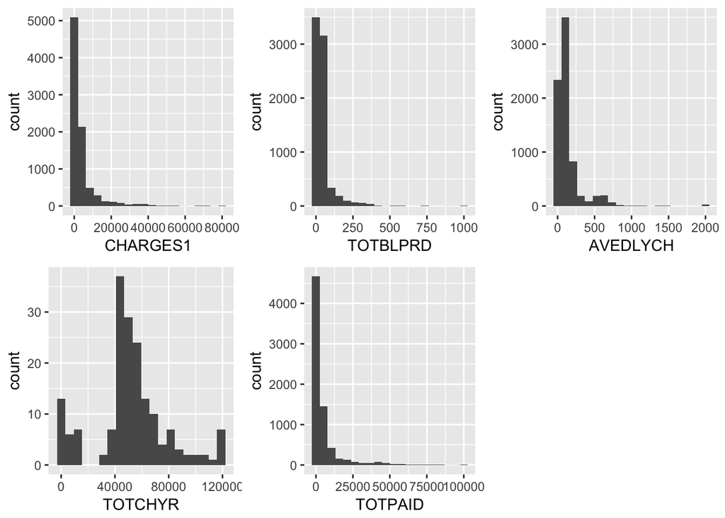

```r
# Visualizing the economic information
ggarrange(
ggplot(filter(hospice_final, CHARGES1 >= 0)) + geom_histogram(mapping = aes(x = CHARGES1), bins = 20),
ggplot(filter(hospice_final, TOTBLPRD >= 0)) + geom_histogram(mapping = aes(x = TOTBLPRD), bins = 20),
ggplot(filter(hospice_final, AVEDLYCH >= 0)) + geom_histogram(mapping = aes(x = AVEDLYCH), bins = 20),
ggplot(filter(hospice_final, TOTCHYR >= 0)) + geom_histogram(mapping = aes(x = TOTCHYR), bins = 20),
ggplot(filter(hospice_final, TOTPAID >= 0)) + geom_histogram(mapping = aes(x = TOTPAID), bins = 20),
ncol = 3,
nrow = 2)
```

**Let’s see if any of them are correlated. We will conduct the correlation test for age separately as there are missing values.**

```r
# Consolidating the quantitative variables
quant <- hospice_final %>%
  select(AGEATINT,
         AGEATDIS,
         PAINLVL1,
         PAINLVL2,
         PAINREC3,
         PAINREC4,
         CHARGES1,
         TOTBLPRD,
         AVEDLYCH,
         TOTCHYR,
         TOTPAID)

quant[quant < 0] <- NA

# Correlation Matrix
cor(quant, use = "pairwise.complete.obs")
```

```
##             AGEATINT    AGEATDIS    PAINLVL1     PAINLVL2    PAINREC3
## AGEATINT  1.00000000          NA          NA           NA -0.02201012
## AGEATDIS          NA  1.00000000 -0.21614563 -0.213211711 -0.12025879
## PAINLVL1          NA -0.21614563  1.00000000           NA  0.31122659
## PAINLVL2          NA -0.21321171          NA  1.000000000  0.30703963
## PAINREC3 -0.02201012 -0.12025879  0.31122659  0.307039628  1.00000000
## PAINREC4  0.09236914 -0.18910622  0.04251794  0.361131954          NA
## CHARGES1 -0.01919326  0.07252983 -0.05604934 -0.028225461 -0.06743752
## TOTBLPRD  0.08318630  0.07375551 -0.04057039 -0.002979537 -0.03986891
## AVEDLYCH -0.06678002  0.02322998 -0.00485793  0.122897615 -0.03835515
## TOTCHYR           NA  0.06174259 -0.11362663 -0.117947433 -0.01129894
## TOTPAID  -0.00777493  0.11337146 -0.05895461 -0.145201049 -0.06892883
##              PAINREC4    CHARGES1     TOTBLPRD     AVEDLYCH     TOTCHYR
## AGEATINT  0.092369136 -0.01919326  0.083186305 -0.066780017          NA
## AGEATDIS -0.189106222  0.07252983  0.073755514  0.023229980  0.06174259
## PAINLVL1  0.042517938 -0.05604934 -0.040570390 -0.004857930 -0.11362663
## PAINLVL2  0.361131954 -0.02822546 -0.002979537  0.122897615 -0.11794743
## PAINREC3           NA -0.06743752 -0.039868910 -0.038355147 -0.01129894
## PAINREC4  1.000000000 -0.06352178 -0.038547192 -0.002526204 -0.21391033
## CHARGES1 -0.063521784  1.00000000  0.694950240  0.127858238          NA
## TOTBLPRD -0.038547192  0.69495024  1.000000000 -0.150573775          NA
## AVEDLYCH -0.002526204  0.12785824 -0.150573775  1.000000000          NA
## TOTCHYR  -0.213910325          NA           NA           NA  1.00000000
## TOTPAID  -0.102520190  0.95369290  0.695631962  0.104191824  0.90751806
##              TOTPAID
## AGEATINT -0.00777493
## AGEATDIS  0.11337146
## PAINLVL1 -0.05895461
## PAINLVL2 -0.14520105
## PAINREC3 -0.06892883
## PAINREC4 -0.10252019
## CHARGES1  0.95369290
## TOTBLPRD  0.69563196
## AVEDLYCH  0.10419182
## TOTCHYR   0.90751806
## TOTPAID   1.00000000
```

**Looking at just the pain levels, there does not appear to be a high level of correlation between the measurements. There were more correlations between the economic variables, such as the total amount billed for the last complete billing session and the total number of days that charge covered, total amount billed for the last complete billing session and the total amount paid to or by the primary payment souce, and total amount billed for the last 12 month before discharge and total amount paid to or by the pirmary payment source.**

### Qualitative Variable Analysis

**Because there were over 300 factor variables, I parsed through the ones that I thought were interesting, specifically, demographic information. Let’s look at the break down of gender, race and marital status.**

```r
# Isolating demographic information
demographic <- hospice_final %>%
   select(SEX,
          HISPAN,
          RACEAMIN,
          RACEASIA,
          RACEBLCK,
          RACEPACI,
          RACEWHT,
          RACEIMP,
          MARSTAT)

demographic[1:9] <- lapply(demographic[1:9], factor)

# Summarizing demographic information
summary(demographic)
```

```
##  SEX      HISPAN    RACEAMIN RACEASIA RACEBLCK RACEPACI RACEWHT  RACEIMP
##  1:3847   -8: 264   1:  82   1:  89   1: 860   1:  26   1:8362   1: 321
##  2:5569   1 : 439   2:9334   2:9327   2:8556   2:9390   2:1054   2:9095
##           2 :8713
##
##
##
##
##     MARSTAT
##  1      :3593
##  2      :3285
##  5      :1059
##  3      : 710
##  -8     : 610
##  6      :  85
##  (Other):  74
```

```r
1059/9416
```

```
## [1] 0.1124681
```

**In our sample, 40.8% were male, which is below the national average proportion. 88.8% of the sample were white, 9.1% were black, 4.7% were Latino, and there were only a small percentage of Asian and Native Americans. 38.2% were married, 34.9% were widowed, and 11.2% had never married. We can use these markers and see if there are any effects in quantitative measures.**

### Qualitative and Quantitative Variable Analysis

**Let’s take an inital look at the effects of demographic factors on quantitative measurements.**

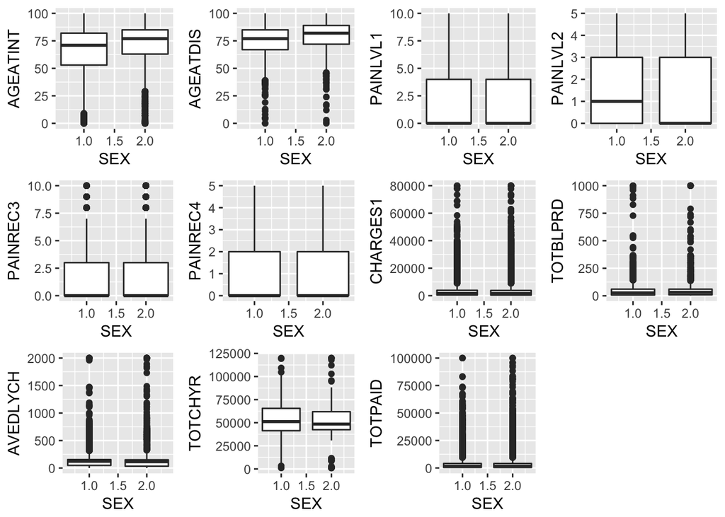

```r
# Setting up effects dataset
effects <- hospice_final %>%
  select(AGEATINT,
         AGEATDIS,
         PAINLVL1,
         PAINLVL2,
         PAINREC3,
         PAINREC4,
         CHARGES1,
         TOTBLPRD,
         AVEDLYCH,
         TOTCHYR,
         TOTPAID,
         SEX,
         RACEETHN,
         MARSTAT
         )

effects[effects < 0] <- NA

# Visualizing gender effects with boxplots
ggarrange(
ggplot(effects) + geom_boxplot(mapping = aes(x = SEX, group = SEX, y = AGEATINT)),
ggplot(effects) + geom_boxplot(mapping = aes(x = SEX, group = SEX, y = AGEATDIS)),
ggplot(effects) + geom_boxplot(mapping = aes(x = SEX, group = SEX, y = PAINLVL1)),
ggplot(effects) + geom_boxplot(mapping = aes(x = SEX, group = SEX, y = PAINLVL2)),
ggplot(effects) + geom_boxplot(mapping = aes(x = SEX, group = SEX, y = PAINREC3)),
ggplot(effects) + geom_boxplot(mapping = aes(x = SEX, group = SEX, y = PAINREC4)),
ggplot(effects) + geom_boxplot(mapping = aes(x = SEX, group = SEX, y = CHARGES1)),
ggplot(effects) + geom_boxplot(mapping = aes(x = SEX, group = SEX, y = TOTBLPRD)),
ggplot(effects) + geom_boxplot(mapping = aes(x = SEX, group = SEX, y = AVEDLYCH)),
ggplot(effects) + geom_boxplot(mapping = aes(x = SEX, group = SEX, y = TOTCHYR)),
ggplot(effects) + geom_boxplot(mapping = aes(x = SEX, group = SEX, y = TOTPAID)),
nrow = 3,
ncol = 4)
```

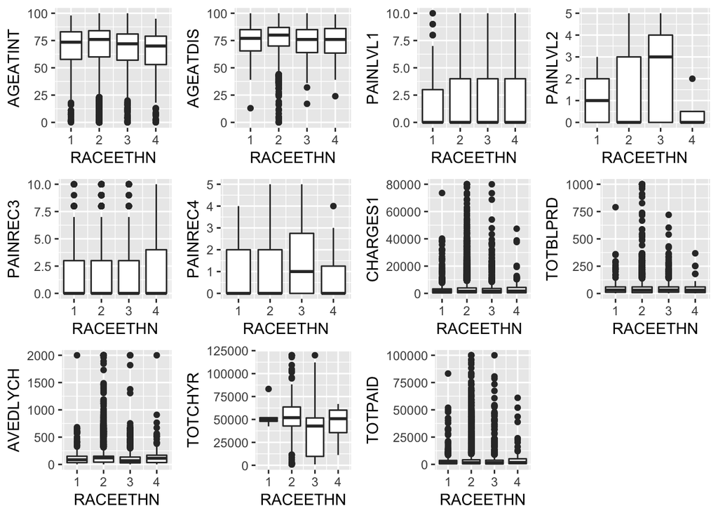

```r
# Visualizing race with boxplots
ggarrange(
ggplot(effects) + geom_boxplot(mapping = aes(x = RACEETHN, group = RACEETHN, y = AGEATINT)),
ggplot(effects) + geom_boxplot(mapping = aes(x = RACEETHN, group = RACEETHN, y = AGEATDIS)),
ggplot(effects) + geom_boxplot(mapping = aes(x = RACEETHN, group = RACEETHN, y = PAINLVL1)),
ggplot(effects) + geom_boxplot(mapping = aes(x = RACEETHN, group = RACEETHN, y = PAINLVL2)),
ggplot(effects) + geom_boxplot(mapping = aes(x = RACEETHN, group = RACEETHN, y = PAINREC3)),
ggplot(effects) + geom_boxplot(mapping = aes(x = RACEETHN, group = RACEETHN, y = PAINREC4)),
ggplot(effects) + geom_boxplot(mapping = aes(x = RACEETHN, group = RACEETHN, y = CHARGES1)),
ggplot(effects) + geom_boxplot(mapping = aes(x = RACEETHN, group = RACEETHN, y = TOTBLPRD)),
ggplot(effects) + geom_boxplot(mapping = aes(x = RACEETHN, group = RACEETHN, y = AVEDLYCH)),
ggplot(effects) + geom_boxplot(mapping = aes(x = RACEETHN, group = RACEETHN, y = TOTCHYR)),
ggplot(effects) + geom_boxplot(mapping = aes(x = RACEETHN, group = RACEETHN, y = TOTPAID)),
nrow = 3,
ncol = 4)
```

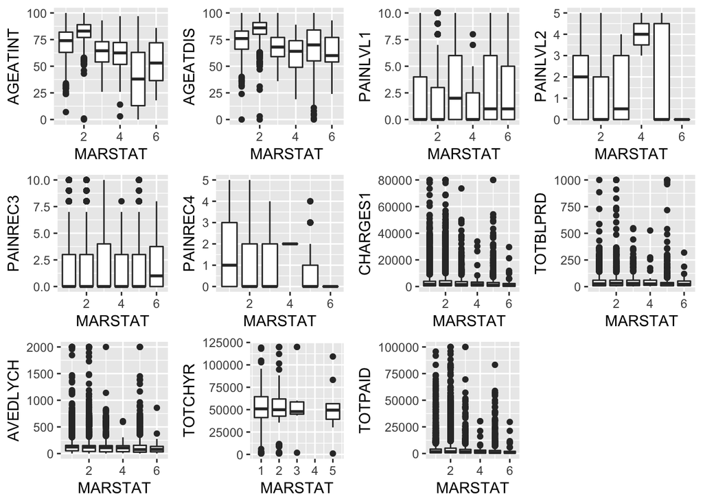

```r
# Visualizing marriage status with boxplots
ggarrange(
ggplot(effects) + geom_boxplot(mapping = aes(x = MARSTAT, group = MARSTAT, y = AGEATINT)),
ggplot(effects) + geom_boxplot(mapping = aes(x = MARSTAT, group = MARSTAT, y = AGEATDIS)),
ggplot(effects) + geom_boxplot(mapping = aes(x = MARSTAT, group = MARSTAT, y = PAINLVL1)),
ggplot(effects) + geom_boxplot(mapping = aes(x = MARSTAT, group = MARSTAT, y = PAINLVL2)),
ggplot(effects) + geom_boxplot(mapping = aes(x = MARSTAT, group = MARSTAT, y = PAINREC3)),
ggplot(effects) + geom_boxplot(mapping = aes(x = MARSTAT, group = MARSTAT, y = PAINREC4)),
ggplot(effects) + geom_boxplot(mapping = aes(x = MARSTAT, group = MARSTAT, y = CHARGES1)),
ggplot(effects) + geom_boxplot(mapping = aes(x = MARSTAT, group = MARSTAT, y = TOTBLPRD)),
ggplot(effects) + geom_boxplot(mapping = aes(x = MARSTAT, group = MARSTAT, y = AVEDLYCH)),
ggplot(effects) + geom_boxplot(mapping = aes(x = MARSTAT, group = MARSTAT, y = TOTCHYR)),
ggplot(effects) + geom_boxplot(mapping = aes(x = MARSTAT, group = MARSTAT, y = TOTPAID)),
nrow = 3,
ncol = 4)
```

**While these bloxplots are useful in visualizing discrepencies, some of them lack enough data points to be useful. It appears that for the most part, sex does not have an effect on any of the quantitative variables. There seems to be some effect on the economic variables when it comes to race and ethnicity, as with marriage status. We will need to conduct ANOVA and tests for equal mean among the groups to see if there are any actual differences and effects.**

### Conclusion from EDA

**From this exploratory data analysis we have identified missing values and some trends between and within variables. More research needs to go into exploring the different groups of categorical variables, and to further examine its effects on other variables.**